# Getting Data Through APIs

David Gerard

2023-10-11

# Learning Objectives

- APIs and R.
- [Chapter 1, 2, and 3 from An Introduction to APIs](https://zapier.com/learn/apis/).
- [Chapter 40 from STAT 545](https://stat545.com/diy-web-data.html).
- [Getting Started with `{httr2}`](https://httr2.r-lib.org/articles/httr2.html)
- [Rectangling](https://tidyr.tidyverse.org/articles/rectangle.html)

# Data on the Web

- There are at least 4 ways people download data on the web:
  1. Click to download a csv/xls/txt file.
  2. Use a package that interacts with an API.
  3. Use an API directly.
  4. Scrape from directly from the HTML file.
- We know how to do 1.
- This lesson is about doing 2 and 3.
- Let’s load the tidyverse:

  ```r
  library(tidyverse)
  ```

# R Package API Wrappers

- API: Application Programming Interface
  - A description of how you can request data from a particular software, and a description of what type of response you get after the request.
  - Usually, the data you get back are XML or JSON files.
  - API’s are an abstraction and can be implemented in many languages.
  - Think of it like a user interface for a computer program. You click a button and expect the user interface to do something. An API let’s a program click a metaphorical “button” and expect to get something back.
  - There are lots of free and public APIs: https://github.com/public-apis/public-apis
- Many of the most popular databases/websites have an R package that wraps the API through R functions.
  - I.e.: You can use an R function to request data.
- If an R package exists for an API, you should use it.
- Examples:
  - tidycensus: U.S. Census data API.

    https://cran.r-project.org/package=tidycensus
  - gh: GitHub API.

    https://cran.r-project.org/package=gh
  - wbstats: World Bank data.

    https://cran.r-project.org/package=wbstats
  - rebird: Ebird dataset for bird sitings.

    https://cran.r-project.org/package=rebird
  - geonames: Dataset containing unique names for geographic locations.

    https://cran.r-project.org/package=geonames
  - WikipediR: Wikipedia API:

    https://cran.r-project.org/package=WikipediR
- Each package will be entirely unique, and you have to read its documentation to know how to download data. So we won’t cover any of them.

# Use API’s directly with httr2

- The goal of this section is not to provide a comprehensive lesson on HTTP and extracting data using API’s. Rather, this is just to point you to some resources and give you some examples.
- Each API is different, and so you’ll always have to figure out how to interact with a new API.
- API’s always have documentation on what parameters you can send, how you can send them, and what data you would get back based on the values of those parameters.
- E.g.: OMDB (an open-source version of IMDB) has a simple API http://www.omdbapi.com/

# Authentication

- Some API’s are public and you just have at them (though, be congnizent that you are not making too many requests).
- Others require authentication to access the API.
- There are three ways that apps authenticate, from easiest to hardest:
  - Using “basic” authentication
  - Using an API key, and
  - Using OAuth.

## Basic Authentication

- “Basic” authentication, where you just provide a username and password. The basic syntax for this is:

  ```r
  req_auth_basic(req, username, password)
  ```

- You should already have a username and password set up.
- I would suggest keeping your password secure using your .Renviron file or via `{keyring}` (see below).

## API keys

- An API key is a string that you add to your request.
- To obtain a free key from OMDB and access it in R:
  1. Sign up for a free key: https://www.omdbapi.com/apikey.aspx
  2. Open up your .Renviron file using the usethis package.

     ```r
     library(usethis)
     edit_r_environ()
     ```

  3. Add the key OMDB sent you by email to the .Renviron package. You can call it `OMDB_API_KEY`, for example. In which case you would write the following in .Renviron:

     ```
     OMDB_API_KEY = <your-private-key>
     ```

     Where “`<your-private-key>`” is the private key OMDB sent you by email.
  4. Restart R.
  5. You can now always access your private key by

     ```r
     movie_key <- Sys.getenv("OMDB_API_KEY")
     ```

  6. You typically put your API key as a query parameter via `req_url_query()` (see below)
- It is important to never save or display your private key in a file you could share. You are responsible for all behavior associated with your key. That is why we saved it to our .Renviron and are only accessing it secretly through `Sys.getenv()`.
- It is still not great that your key is in a plain text environment. You can add a layer of security by using the keyring package: https://github.com/r-lib/keyring

  ```r
  library(keyring)
  key_set("OMDB_API_KEY_SECURE") ## do this once to save the key
  movie_key_2 <- key_get("OMDB_API_KEY_SECURE") ## do this each time you need the key
  ```

  A person with access to your computer who knows R and the keyring package could still get to your key. But it is more secure than placing your key in a plain text file (which is what .Renviron is). There are more secure ways to access keys in R.

## OAuth:

- See [OAuth](https://httr2.r-lib.org/articles/oauth.html) from `{httr2}` for details.
- OAuth (“Open Authorization”) is an open standard for authorization that allows users to securely access resources without giving away their login credentials.
- The idea is that your software asks the user if it can use the user’s authorization to access the API.
  - It does this each time it needs to access the API.
  - This is commonly used in big API’s, like that of Google, Twitter, or Facebook.
- As an example, we will consider the [GitHub API](http://developer.github.com/v3/oauth/).
1. “Register an application” with the API provider before you can access the API.
   - You do this by creating a developer account on the API’s website, then registering a new OAuth app.
   - You won’t actually have an app, but API developers use this word for any means where you ask to use a user’s authorization.
   - This typically involves providing a name and a callback URL (typically http://localhost:1410) for your “application”.
   - For GitHub:
     - Register at https://github.com/settings/developers
     - Use any URL (like https://github.com/) as your homepage URL
     - Use http://localhost:1410 as the callback url.
2. The provider will then give you a `client_id` and a `client_secret` that you will need to use.
   - Neither of these need to be protected like a password since the user will provide their own password/username for authentication.
   - For GitHub:
     - You can find these here: https://github.com/settings/developers
     - Click on your OAuth app.
3. Obtain a “token URL”, which is sometimes called an “access URL”.
   - This can be found somewhere in the API docs, but you have to read them carefully.
   - For GitHub:
     - The access URL is https://github.com/login/oauth/access_token
4. Use `oauth_client()` to create a client. You feed in the `client_id`, the `client_secret`, the `toeken_url`, and any name you choose into it.

   ```r
   client <- oauth_client(
     id = "client_id",
     secret = "client_secret",
     token_url = "token_url",
     name = "personal_app_name"
   )
   ```

   - For GitHub:

     ```r
     client <- oauth_client(
       id = "933ffc6f53e466c58aa1",
       secret = "aa02ef46f93aa51a360f23f30f7640b445118e7f",
       token_url = "https://github.com/login/oauth/access_token",
       name = "gitapp"
     )
     ```

5. You get an “authorization URL”.
   - This again can be found somewhere in the docs.
   - For GitHub:
     - The autorization URL is: https://github.com/login/oauth/authorize

       ```r
       auth_url <- "https://github.com/login/oauth/authorize"
       ```

6. Feed the authorization URL and the client into `req_oauth_auth_code()` during a request.

   ```r
   request("https://api.github.com/user") |>
     req_oauth_auth_code(client = client, auth_url = auth_url) |>
     req_perform() ->
     gout
   gout
   ```

- There are sometimes other “flows” for OAuth that require different steps. See here for details: https://httr2.r-lib.org/articles/oauth.html
- When using OAuth in a package, folks often (i) “cache” the token securely (because the generated token should be kept private), and (ii) ask folks to generate their own app.
- Caching is easy. Just set `cache_disk = TRUE` in `req_oauth_auth_code()`.
  - Note that this creates some security risks since the token will be saved on the disk.
  - So you should inform the user if you do this.
- When you ask folks to generate their own app, then you should have `client_id` and `client_secret` as arguments that the user can provide.

# httr2

- Most API’s on the web use HTTP (Hyper-Text Transfer Protocol). It’s a language for querying and obtaining data.
- We won’t learn HTTP, but we will use R’s interface for HTTP through the `{httr2}` package.

  ```r
  library(httr2)
  ```

- To request data from a API, you typically take these steps:
  - Create a request with a base URL via `request()`.
  - Modify this request by some or all of the following:
    - Modifying the endpoint URL with `req_url_path_append()`.
    - Adding Queries to the URL with `req_url_query()`.
    - Adding Headers to the request with `req_headers()`.
    - Adding OAuath via `req_oauth_auth_code()`
    - Specify the HTTP method with `req_method()`
      - `GET` will fetch data.
        - This is the default, so typically you don’t need to specify it explicitly.
      - `PUT` will add stuff to the target.
      - `DELETE` will delete stuff at the target.
      - etc…
  - You should eyeball the http request via `req_dry_run()` and check that it is correct.
  - Send the request with `req_perform()`.
- Some API’s only modify the URL path, some only modify the query, some require headers. Let’s go through each of these in turn.

## URL Path

- Every API has a base URL that you modify.
- Some API’s only modify the URL *path* to obtain the endpoint.
- Consider the [Wizard World API](https://wizard-world-api.herokuapp.com/swagger/index.html)
- The documentation says that the base URL is “https://wizard-world-api.herokuapp.com”.

  ```r
  baseurl <- "https://wizard-world-api.herokuapp.com"
  ```

- Let’s start a request with this baseurl via `request()`.

  ```r
  wizreq <- request(baseurl)
  ```

- The documentation just says that we modify this URL to obtain the different objects. - E.g., to obtain a list of all elixirs that occur in Harry Potter, we just add “Elixirs” at the end.
  - We can do this to our request with `req_url_path_append()`

  ```r
  wizreq <- req_url_path_append(wizreq, "Elixirs")
  wizreq
  ```

  ```
  ## <httr2_request>
  ```

  ```
  ## GET https://wizard-world-api.herokuapp.com/Elixirs
  ```

  ```
  ## Body: empty
  ```

- Let’s look at the http request

  ```r
  req_dry_run(wizreq)
  ```

  ```
  ## GET /Elixirs HTTP/1.1
  ## Host: wizard-world-api.herokuapp.com
  ## User-Agent: httr2/0.2.3 r-curl/5.1.0 libcurl/7.81.0
  ## Accept: */*
  ## Accept-Encoding: deflate, gzip, br, zstd
  ```

- We then implement this request via `req_perform()`.

  ```r
  eout <- req_perform(wizreq)
  eout
  ```

  ```
  ## <httr2_response>
  ```

  ```
  ## GET https://wizard-world-api.herokuapp.com/Elixirs
  ```

  ```
  ## Status: 200 OK
  ```

  ```
  ## Content-Type: application/json
  ```

  ```
  ## Body: In memory (62284 bytes)
  ```

- We would then clean this output (see rectangling below). But as a preview, we would do

  ```r
  tibble(elixir = resp_body_json(resp = eout)) |>
    unnest_wider(col = elixir)
  ```

  ```
  ## # A tibble: 145 × 10
  ##    id      name  effect sideEffects characteristics time  difficulty ingredients
  ##    <chr>   <chr> <chr>  <chr>       <chr>           <chr> <chr>      <list>
  ##  1 0106fb… Ferg… Treat… Potential … <NA>            <NA>  Unknown    <list [3]>
  ##  2 021b40… Mane… Rapid… <NA>        <NA>            <NA>  Unknown    <NULL>
  ##  3 024f56… Poti… <NA>   <NA>        <NA>            <NA>  Unknown    <NULL>
  ##  4 06beea… Rudi… Helps… <NA>        <NA>            <NA>  Unknown    <list [2]>
  ##  5 078b53… Lung… Most … <NA>        <NA>            <NA>  Unknown    <NULL>
  ##  6 07944d… Esse… Menta… <NA>        Green in colour <NA>  Advanced   <list [2]>
  ##  7 0dd8d2… Anti… Cures… <NA>        Green in colour <NA>  Moderate   <list [4]>
  ##  8 0e2240… Rest… Rever… <NA>        Purple coloured <NA>  Unknown    <NULL>
  ##  9 0e7228… Skel… Resto… <NA>        Smokes when po… <NA>  Moderate   <list [6]>
  ## 10 0e7f89… Chee… <NA>   <NA>        Yellow in colo… <NA>  Advanced   <list [1]>
  ## # ℹ 135 more rows
  ## # ℹ 2 more variables: inventors <list>, manufacturer <chr>
  ```

## Queries

- Some APIs require you to modify the URL via *queries*. Queries occur after a question mark and are of the form `http://www.url.com/?query1=arg1&query2=ar2&query3=arg3`
- The [OMDB API](https://www.omdbapi.com/) requires you to provide queries. The documentation says

  > Send all data requests to: [http://www.omdbapi.com/?apikey=[yourkey]&](http://www.omdbapi.com/?apikey=%5Byourkey%5D&)

  But that documentation already has a query as a part of it (apikey=[yourkey]).
- You add queries via `req_url_query()`.
  - You provide it with name/value paires.
- The documentation for OMDB has a table called “Parameters”, where they list the possible queries.
- Let’s fetch information on the film The Lighthouse, obtaining a short plot in json format.
- This is what the URL looks like without my API key:

  ```r
  movie_key <- Sys.getenv("OMDB_API_KEY")
  request("http://www.omdbapi.com/") |>
    req_url_query(t = "The Lighthouse",
                  plot = "short",
                  r = "json") ->
    movie_req
  movie_req
  ```

  ```
  ## <httr2_request>
  ```

  ```
  ## GET http://www.omdbapi.com/?t=The%20Lighthouse&plot=short&r=json
  ```

  ```
  ## Body: empty
  ```

- Let’s add our API key and perform the request.

  ```r
  movie_req |>
    req_url_query(apikey = movie_key) |>
    req_perform() ->
    mout
  mout
  ```

  ```
  ## <httr2_response>
  ```

  ```
  ## GET
  ## http://www.omdbapi.com/?t=The%20Lighthouse&plot=short&r=json&apikey=18375155
  ```

  ```
  ## Status: 200 OK
  ```

  ```
  ## Content-Type: application/json
  ```

  ```
  ## Body: In memory (994 bytes)
  ```

- Output is just a list:

  ```r
  resp_body_json(mout) |>
    str()
  ```

  ```
  ## List of 25
  ##  $ Title     : chr "The Lighthouse"
  ##  $ Year      : chr "2019"
  ##  $ Rated     : chr "R"
  ##  $ Released  : chr "01 Nov 2019"
  ##  $ Runtime   : chr "109 min"
  ##  $ Genre     : chr "Drama, Fantasy, Horror"
  ##  $ Director  : chr "Robert Eggers"
  ##  $ Writer    : chr "Robert Eggers, Max Eggers"
  ##  $ Actors    : chr "Robert Pattinson, Willem Dafoe, Valeriia Karaman"
  ##  $ Plot      : chr "Two lighthouse keepers try to maintain their sanity while living on a remote and mysterious New England island in the 1890s."
  ##  $ Language  : chr "English"
  ##  $ Country   : chr "United States, Canada"
  ##  $ Awards    : chr "Nominated for 1 Oscar. 33 wins & 134 nominations total"
  ##  $ Poster    : chr "https://m.media-amazon.com/images/M/MV5BZmE0MGJhNmYtOWNjYi00Njc5LWE2YjEtMWMxZTVmODUwMmMxXkEyXkFqcGdeQXVyMTkxNjU"| __truncated__
  ```

  [output cut: 20 more lines]

- In the API documentation:

[figure not shown]

## Headers

- Headers supply additional options for the return type.
- Common headers are described by Wikipedia: https://en.wikipedia.org/wiki/List_of_HTTP_header_fields
- You supply headers to a request via `req_headers()`.
- Consider the [icanhazdadjoke](https://icanhazdadjoke.com/api) API. One option is to include a header to specify plain text returns, rather than JSON returns.

  ```r
  request("https://icanhazdadjoke.com/") |>
    req_headers(Accept = "text/plain") |>
    req_perform() ->
    dadout
  dadout
  resp_body_string(dadout)
  ```

- This is different than a JSON output

  ```r
  request("https://icanhazdadjoke.com/") |>
    req_perform() ->
    dadout2
  resp_body_string(dadout2)
  ```

## Output:

- Functions that work with the response are all of the form `resp_*()`.
- The *status code* describes whether your request was successful.
  - List of codes: https://http.cat/
  - Use `resp_status()` to get the code for our request:

    ```r
    resp_status(mout)
    ```

    ```
    ## [1] 200
    ```

- *Headers* provide infromation on the request. Use the `resp_headers()` function to see what headers we got in our request.

  ```r
  resp_headers(mout)
  ```

- The *body* contains the data you are probably most interested in. Use the `resp_body_*()` functions to access the body:

  ```r
  resp_body_json(mout)
  ```

- Background: The body typically comes in the form of either a JSON or XML data structure.
  - For JSON, you use `resp_body_json()`
  - For XML you use `resp_body_xml()`
  - You can see the unparsed output with `resp_body_string()`

  ```r
  resp_body_string(mout)
  ```

  ```
  ## [1] "{\"Title\":\"The Lighthouse\",\"Year\":\"2019\",\"Rated\":\"R\",\"Released\":\"01 Nov 2019\",\"Runtime\":\"109 min\",\"Genre\":\"Drama, Fantasy, Horror\",\"Director\":\"Robert Eggers\",\"Writer\":\"Robert Eggers, Max Eggers\",\"Actors\":\"Robert Pattinson, Willem Dafoe, Valeriia Karaman\",\"…
  ```

- `resp_header("content-type")` will often tell you the type of body output.

  ```r
  resp_header(mout, "content-type")
  ```

  ```
  ## [1] "application/json; charset=utf-8"
  ```

  ```r
  resp_header(eout, "content-type")
  ```

  ```
  ## [1] "application/json; charset=utf-8"
  ```

# Rectangling

- The format for the data you typically get from an API is a list of lists.
- The `repurrrsive` package contains a few examples.

  ```r
  library(repurrrsive)
  ```

- The dataset `gh_users` contains information from 6 users, obtained using GitHub’s API: https://developer.github.com/v3/users/#get-a-single-user

  ```r
  data("gh_users")
  typeof(gh_users)
  ```

  ```
  ## [1] "list"
  ```

  ```r
  length(gh_users)
  ```

  ```
  ## [1] 6
  ```

  ```r
  names(gh_users[[1]])
  ```

  ```
  ##  [1] "login"               "id"                  "avatar_url"
  ##  [4] "gravatar_id"         "url"                 "html_url"
  ##  [7] "followers_url"       "following_url"       "gists_url"
  ## [10] "starred_url"         "subscriptions_url"   "organizations_url"
  ## [13] "repos_url"           "events_url"          "received_events_url"
  ## [16] "type"                "site_admin"          "name"
  ## [19] "company"             "blog"                "location"
  ## [22] "email"               "hireable"            "bio"
  ## [25] "public_repos"        "public_gists"        "followers"
  ## [28] "following"           "created_at"          "updated_at"
  ```

- There are a few functions from `tidyr` package that can be used to “unnest” a list into a data frame.
  - `unnest_wider()`: Each list element becomes its own column
  - `hoist()`: Similar as `unnest_wider()`, but you can choose what elements to extract to their own columns.
  - `unnest_longer()`: Each list element becomes its own row.
- Because this is the tidyverse, your list needs to be a column in a data frame:

  ```r
  df <- tibble(users = gh_users)
  df
  ```

  ```
  ## # A tibble: 6 × 1
  ##   users
  ##   <list>
  ## 1 <named list [30]>
  ## 2 <named list [30]>
  ## 3 <named list [30]>
  ## 4 <named list [30]>
  ## 5 <named list [30]>
  ## 6 <named list [30]>
  ```

- In which case, you can consider the unnest functions via:
  - `unnest_wider()` preserves the rows, but changes the columns.
  - `unnest_longer()` preserves the columns, but changes the rows
- Use `unnest_wider()` to make each of those list elements their own column.

  ```r
  unnest_wider(df, users)
  ```

  ```
  ## # A tibble: 6 × 30
  ##   login     id avatar_url gravatar_id url   html_url followers_url following_url
  ##   <chr>  <int> <chr>      <chr>       <chr> <chr>    <chr>         <chr>
  ## 1 gabo… 6.60e5 https://a… ""          http… https:/… https://api.… https://api.…
  ## 2 jenn… 5.99e5 https://a… ""          http… https:/… https://api.… https://api.…
  ## 3 jtle… 1.57e6 https://a… ""          http… https:/… https://api.… https://api.…
  ## 4 juli… 1.25e7 https://a… ""          http… https:/… https://api.… https://api.…
  ## 5 leep… 3.51e6 https://a… ""          http… https:/… https://api.… https://api.…
  ## 6 masa… 8.36e6 https://a… ""          http… https:/… https://api.… https://api.…
  ## # ℹ 22 more variables: gists_url <chr>, starred_url <chr>,
  ## #   subscriptions_url <chr>, organizations_url <chr>, repos_url <chr>,
  ## #   events_url <chr>, received_events_url <chr>, type <chr>, site_admin <lgl>,
  ## #   name <chr>, company <chr>, blog <chr>, location <chr>, email <chr>,
  ## #   hireable <lgl>, bio <chr>, public_repos <int>, public_gists <int>,
  ## #   followers <int>, following <int>, created_at <chr>, updated_at <chr>
  ```

- Graphic:

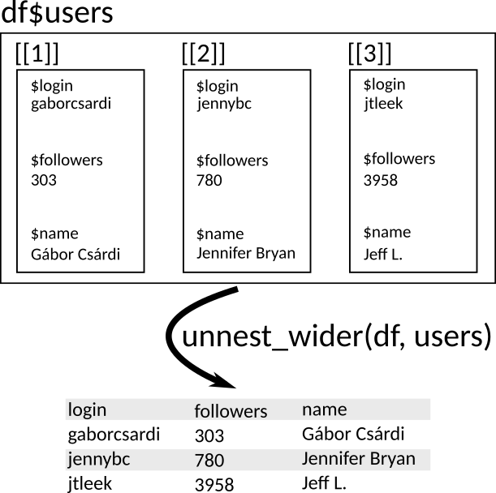

- Use `hoist()` to only extract some elements of a list:

  ```r
  df2 <- hoist(df, users,
               login = "login",
               followers = "followers")
  df2
  ```

  ```
  ## # A tibble: 6 × 3
  ##   login       followers users
  ##   <chr>           <int> <list>
  ## 1 gaborcsardi       303 <named list [28]>
  ## 2 jennybc           780 <named list [28]>
  ## 3 jtleek           3958 <named list [28]>
  ## 4 juliasilge        115 <named list [28]>
  ## 5 leeper            213 <named list [28]>
  ## 6 masalmon           34 <named list [28]>
  ```

- Notice that the new data frame still has a list column, but each each list now only has 28 elements instead of 30. That’s because `hoist()` has removed the `login` and `followers` elements from each list in the list column.

  ```r
  df2$users[[1]]["login"]
  ```

  ```
  ## $<NA>
  ## NULL
  ```

  ```r
  df2$users[[1]]["followers"]
  ```

  ```
  ## $<NA>
  ## NULL
  ```

- Graphic:

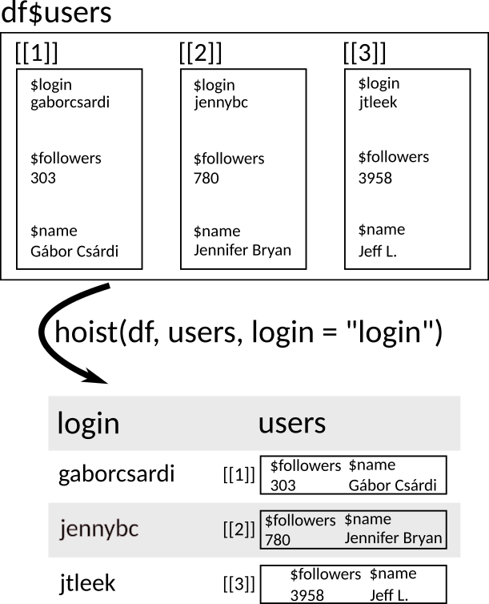

- Let’s look at the list `gh_repos`, which was also obtained using the GitHub API: https://developer.github.com/v3/repos/#list-user-repositories

  ```r
  data("gh_repos")
  typeof(gh_repos)
  ```

  ```
  ## [1] "list"
  ```

  ```r
  length(gh_repos)
  ```

  ```
  ## [1] 6
  ```

  ```r
  df <- tibble(repo = gh_repos)
  df
  ```

  ```
  ## # A tibble: 6 × 1
  ##   repo
  ##   <list>
  ## 1 <list [30]>
  ## 2 <list [30]>
  ## 3 <list [30]>
  ## 4 <list [26]>
  ## 5 <list [30]>
  ## 6 <list [30]>
  ```

- This list is very complicated!

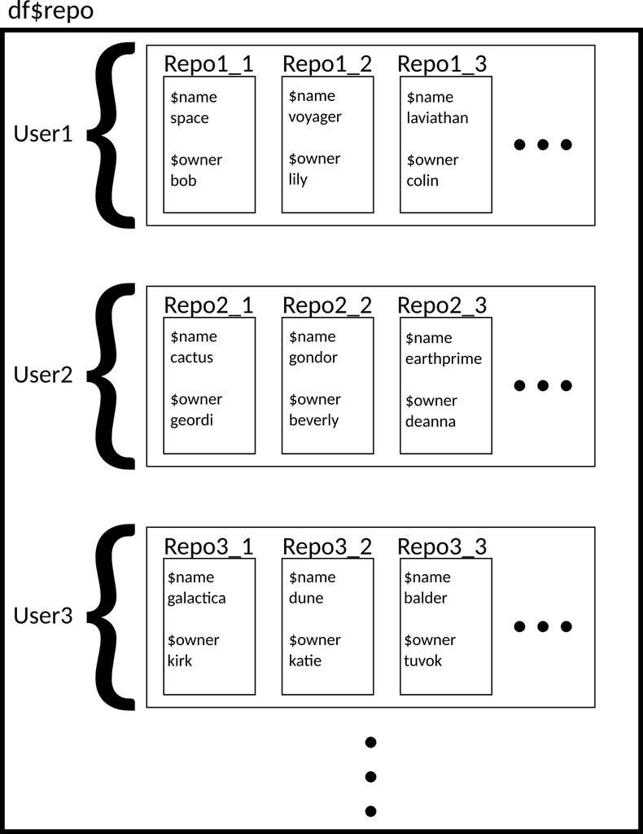

- Ideally, each repo would be its own row (since the repositories are the observational units). We can do this with `unnest_longer()`.

  ```r
  df2 <- unnest_longer(df, repo)
  df2
  ```

  ```
  ## # A tibble: 176 × 1
  ##    repo
  ##    <list>
  ##  1 <named list [68]>
  ##  2 <named list [68]>
  ##  3 <named list [68]>
  ##  4 <named list [68]>
  ##  5 <named list [68]>
  ##  6 <named list [68]>
  ##  7 <named list [68]>
  ##  8 <named list [68]>
  ##  9 <named list [68]>
  ## 10 <named list [68]>
  ## # ℹ 166 more rows
  ```

- Graphic:

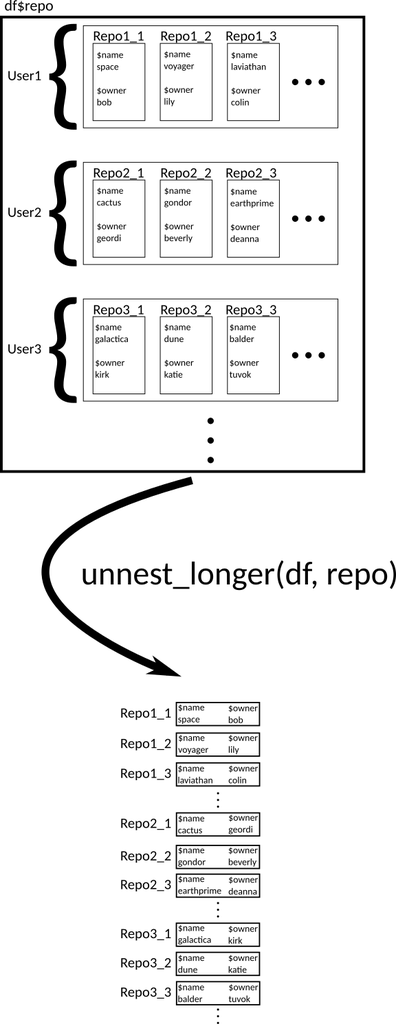

- We can then use `unnest_wider()` or `hoist()` on this new data frame to get a tidy dataset.

  ```r
  df3 <- unnest_wider(df2, repo)
  df3
  ```

  ```
  ## # A tibble: 176 × 68
  ##         id name  full_name owner        private html_url description fork  url
  ##      <int> <chr> <chr>     <list>       <lgl>   <chr>    <chr>       <lgl> <chr>
  ##  1  6.12e7 after gaborcsa… <named list> FALSE   https:/… Run Code i… FALSE http…
  ##  2  4.05e7 argu… gaborcsa… <named list> FALSE   https:/… Declarativ… FALSE http…
  ##  3  3.64e7 ask   gaborcsa… <named list> FALSE   https:/… Friendly C… FALSE http…
  ##  4  3.49e7 base… gaborcsa… <named list> FALSE   https:/… Do we get … FALSE http…
  ##  5  6.16e7 cite… gaborcsa… <named list> FALSE   https:/… Test R pac… TRUE  http…
  ##  6  3.39e7 clis… gaborcsa… <named list> FALSE   https:/… Unicode sy… FALSE http…
  ##  7  3.72e7 cmak… gaborcsa… <named list> FALSE   https:/… port of cm… TRUE  http…
  ##  8  6.80e7 cmark gaborcsa… <named list> FALSE   https:/… CommonMark… TRUE  http…
  ##  9  6.32e7 cond… gaborcsa… <named list> FALSE   https:/… <NA>        TRUE  http…
  ## 10  2.43e7 cray… gaborcsa… <named list> FALSE   https:/… R package … FALSE http…
  ## # ℹ 166 more rows
  ## # ℹ 59 more variables: forks_url <chr>, keys_url <chr>,
  ## #   collaborators_url <chr>, teams_url <chr>, hooks_url <chr>,
  ## #   issue_events_url <chr>, events_url <chr>, assignees_url <chr>,
  ## #   branches_url <chr>, tags_url <chr>, blobs_url <chr>, git_tags_url <chr>,
  ## #   git_refs_url <chr>, trees_url <chr>, statuses_url <chr>,
  ## #   languages_url <chr>, stargazers_url <chr>, contributors_url <chr>, …
  ```

- Graphic:

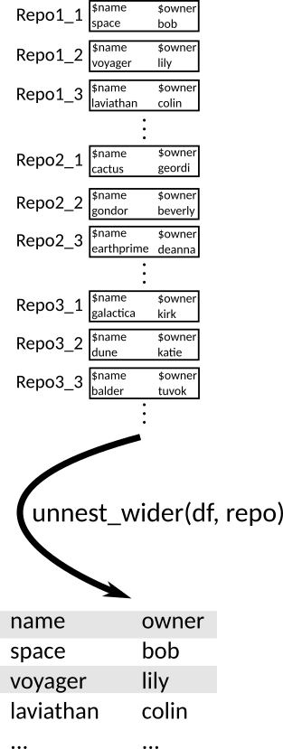

- **Exercise**: Clean up the `sw_people` list from the `repurrrsive` package:

  ```r
  library(repurrrsive)
  data("sw_people")
  ```

- **Exercise**: Clean up the `got_chars` list from the `repurrrsive` package

  ```r
  library(repurrrsive)
  data("got_chars")
  ```

# NASA Exercise

Consider the [NASA API](https://api.nasa.gov/)

1. Generate an API key and save it as `NASA_API_KEY` in your R environment file.
2. Read about the APOD API and obtain all images from January of 2022.
3. Clean the output into a data frame, like this:

   ```
   ## # A tibble: 31 × 8
   ##    copyright      date  explanation hdurl media_type service_version title url
   ##    <chr>          <chr> <chr>       <chr> <chr>      <chr>           <chr> <chr>
   ##  1 "Soumyadeep M… 2022… very Full … http… image      v1              The … http…
   ##  2 "\nDani Caxet… 2022… Sometimes … http… image      v1              Quad… http…
   ##  3 "\nJan Hatten… 2022… You couldn… http… image      v1              Come… http…
   ##  4  <NA>          2022… What's hap… http… image      v1              Moon… http…
   ##  5 "\nLuca Vanze… 2022… Does the S… http… image      v1              A Ye… http…
   ##  6 "Tamas Ladany… 2022… That's not… http… image      v1              The … http…
   ##  7 "Point Blue C… 2022… A male Ade… http… image      v1              Ecst… http…
   ##  8 "Cheng Luo"    2022… Named for … http… image      v1              Quad… http…
   ##  9  <NA>          2022… What will … http… image      v1              Hubb… http…
   ## 10  <NA>          2022… Why does C… <NA>  video      v1              Come… http…
   ## # ℹ 21 more rows
   ```